## Broadcom Inc (AVGO)

**Exchange**: NASDAQ | **Sector**: MANUFACTURING | **Industry**: SEMICONDUCTORS & RELATED DEVICES

### Overview

In the high-tech semiconductor and infrastructure technology sector, this company designs and manufactures critical technological components that power digital infrastructure across enterprise, telecommunications, cloud computing, and industrial markets. Their comprehensive product portfolio spans semiconductor technologies, networking hardware and software, broadband and wireless communication components, data center technologies, and storage system solutions. By providing essential technological building blocks, the company enables advanced digital communication and computing capabilities for enterprise technology companies, telecommunications providers, cloud operators, and industrial equipment manufacturers.

tldr; A technology components manufacturer delivering semiconductor and infrastructure solutions across multiple critical digital technology domains.

Key Comps: - **Intel Corporation** - **Qualcomm** - **NVIDIA** - **Texas Instruments** - **Cisco Systems**

### Charts

#### Price History

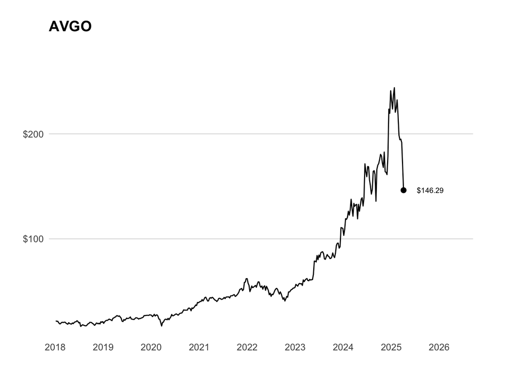

#### Market Cap History

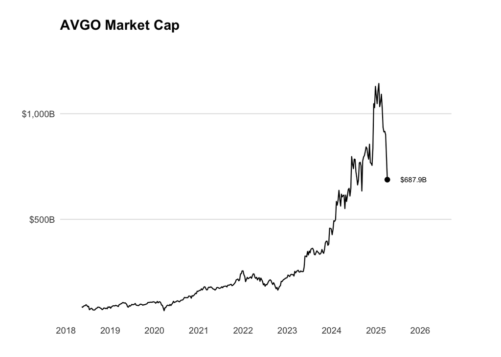

#### Price/EBIT

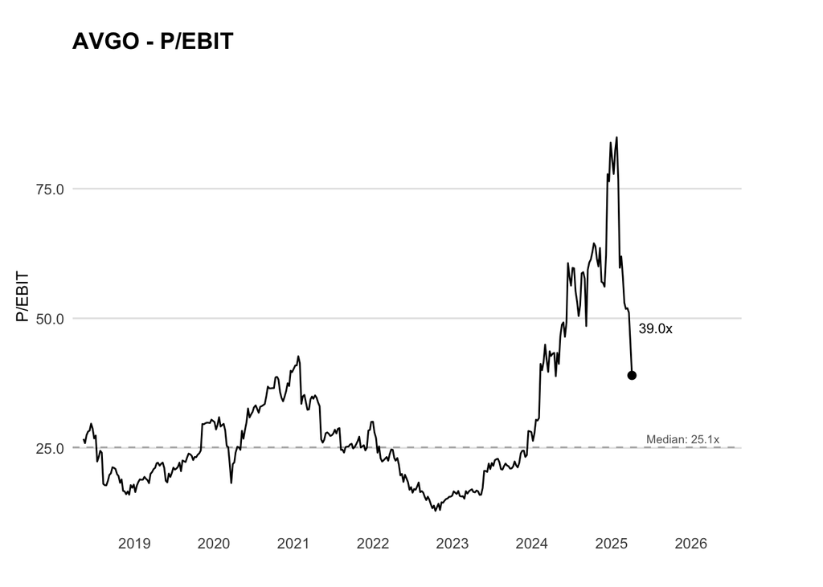

#### EBIT Growth

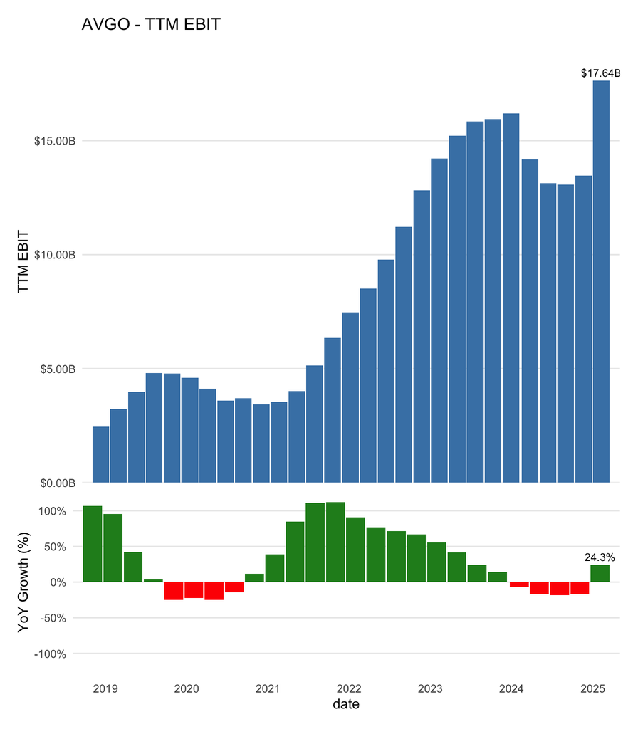

#### Price/Gross Profit

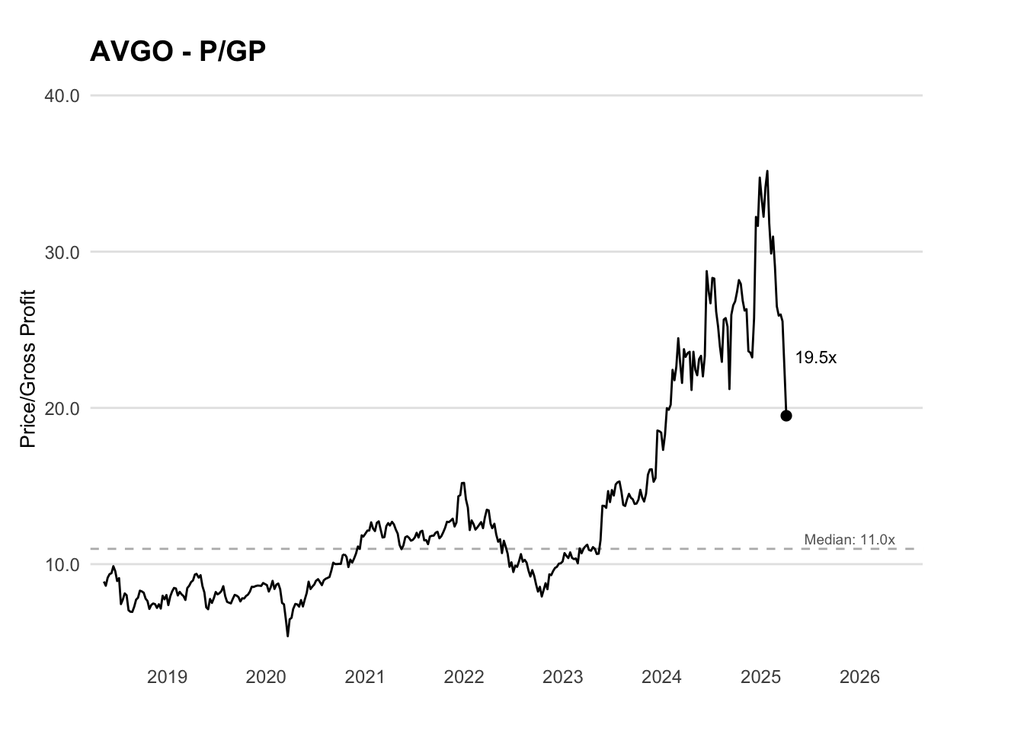

#### Gross Profit Growth

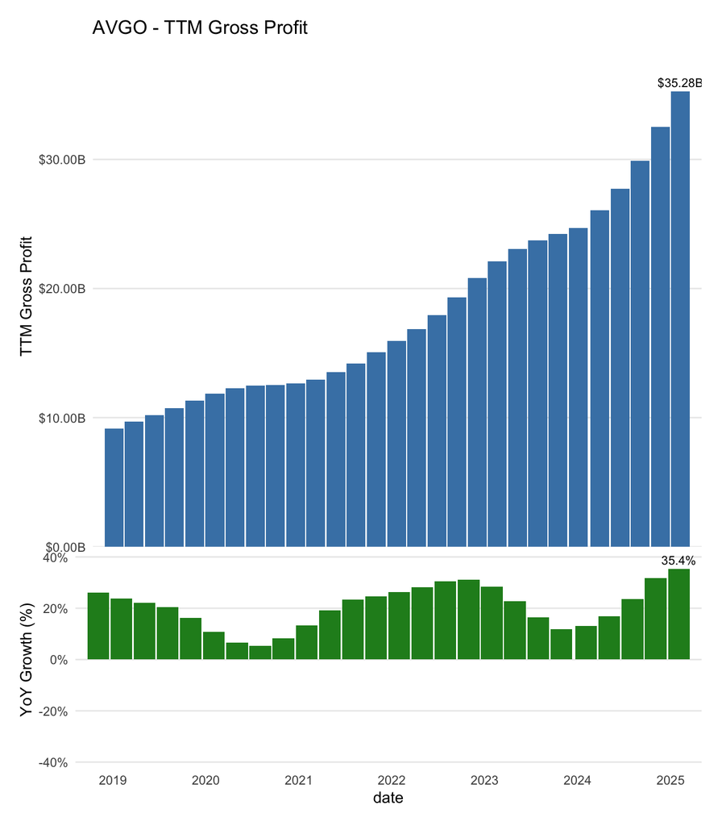

#### Drawdown Analysis

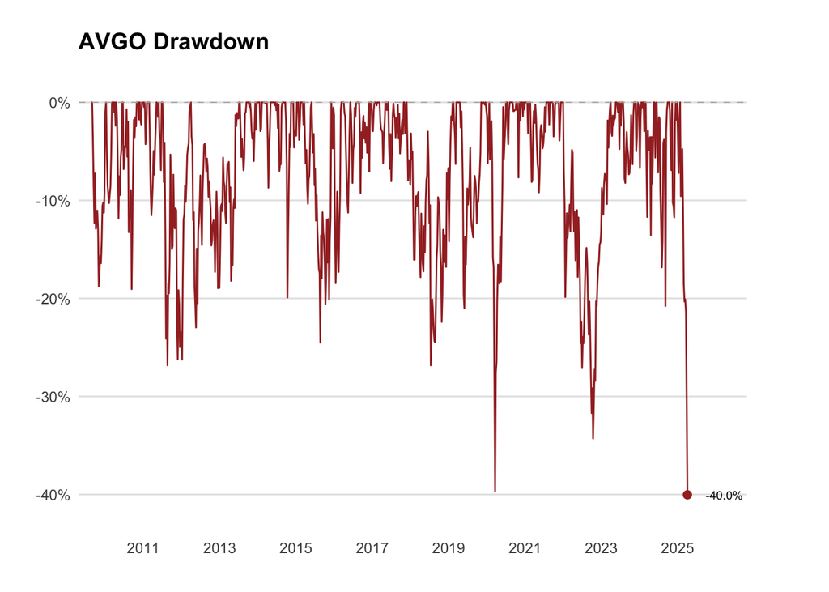

### Metrics

| Market Cap | $687.85B | Revenue TTM | $54.53B | EPS (Diluted) | $2.16 |
| --- | --- | --- | --- | --- | --- |
| P/E (TTM) | 67.73 | Gross Profit | $41.58B | Book Value/Share | $59.22 |
| Forward P/E | 23.53 | EBITDA | $28.84B | Dividend/Share | $2.23 |
| EV/EBITDA | 28.11 | Operating Margin | 31.80% | Dividend Yield | 1.53% |
| EV/Revenue | 14.33 | Profit Margin | 18.50% | Shares Out. | 4,702M |
| Price/Sales | 12.61 | ROE | 14.80% | 52-Week High | $250.45 |
| Price/Book | 10.38 | ROA | 6.98% | 52-Week Low | $118.31 |

### Business Narrative

Broadcom is a semiconductor and infrastructure software company that has strategically positioned itself at the epicenter of AI infrastructure development, primarily by designing custom AI accelerators (XPUs) and high-performance networking solutions for hyperscale cloud customers. The company’s long-term trajectory appears highly promising, with management projecting a serviceable addressable market of $60-$90 billion by fiscal 2027 from just three current customers, and now engaging with four additional hyperscalers to develop custom AI acceleration solutions. Broadcom’s key competitive advantages stem from its hardware engineering expertise, demonstrated ability to create highly specialized silicon that optimizes complex AI workloads, and a disciplined approach to customer selection - focusing only on large-scale, sustainable deployments rather than chasing every potential design win. The most exciting aspect of their strategy is their deep vertical integration, spanning compute (XPUs), networking (switches), and infrastructure software (VMware), which allows them to optimize entire AI computing ecosystems. Their methodical, engineering-driven approach to AI infrastructure development, coupled with their track record of working closely with hyperscale customers to create purpose-built solutions, suggests they are not just a participant but potentially a critical architect of the next generation of AI computing infrastructure. The primary potential concern is the rapid technological evolution in AI, which could render current designs obsolete, but Broadcom seems to mitigate this risk through continuous R&D investment and close customer collaboration.

### Earnings Call Analysis

Here’s an objective analysis of the key business fundamentals from Broadcom’s 2025 Q1 earnings:

Actual Results: - Total revenue: $14.9B (up 25% YoY) - Semiconductor revenue: $8.2B (up 11% YoY) - Infrastructure software revenue: $6.7B (up 47% YoY) - Adjusted EBITDA: $10.1B (68% margin) - Free cash flow: $6B (40% of revenue)

Segment Performance: AI Business: - Q1 AI revenue: $4.1B (up 77% YoY) - Q2 AI revenue guidance: $4.4B (up 44% YoY) - Currently serving 3 major hyperscale customers - 4 new hyperscale partnerships in development

Non-AI Semiconductor Business ($4.1B): - Broadband: Shows recovery with double-digit sequential growth - Server storage: Down single digits in Q1, expecting high single-digit growth in Q2 - Enterprise networking: Flat due to inventory issues - Wireless: Flat YoY with seasonal decline - Industrial: Down double digits with continued weakness expected

Infrastructure Software: - Strong growth driven by subscription transition (60% complete) - 70% of top 10,000 customers adopted VCF platform - 39 enterprise customers for VMware Private AI Foundation

Forward Guidance (Q2): - Total revenue: $14.9B (up 19% YoY) - Semiconductor revenue: $8.4B (up 17% YoY) - Software revenue: $6.5B (up 23% YoY) - Adjusted EBITDA margin: ~66%

Key Developments: - Increased R&D investment in 2nm AI processors - New Tomahawk 6 switch development for larger AI clusters - Expansion of hyperscale partnerships for custom AI accelerators - Continued transition of software business to subscription model

Material Risks/Challenges: - Slow recovery in non-AI semiconductor segments - Ongoing channel inventory issues in enterprise networking - Industrial segment weakness - High interest expenses from VMware acquisition debt

The results show strong momentum in AI and software while traditional semiconductor segments face mixed conditions. Management’s narrative aligns with the reported metrics, though the forward-looking statements about hyperscale partnerships require validation through future results.

### Analyst Q&A Insights

Here’s my analysis of the Q&A dynamics:

Key Themes in Analyst Questioning:

1. New Customer Pipeline & Execution Risk
- Multiple analysts probed about the “4 new partners” vs “3 existing customers” distinction
- Questions focused on conversion from design wins to actual deployment
- Concerns about execution risk and timeline to revenue
- Skepticism about potential scale of new partners vs existing customers
2. Market Share & Competition Dynamics
- Questions about inference vs training workloads suggest concern about competitive positioning
- Analysts probed about GPU vs XPU architecture choices
- Interest in Ethernet/networking competitive advantages
3. Regulatory/Geopolitical Risk
- Questions about tariffs and export controls
- Specific concerns about AI diffusion rules impact
- Focus on China-related risks

Management Response Analysis:

Strengths: - Very detailed technical responses about XPU architecture and networking - Clear articulation of customer engagement model - Specific metrics shared about timelines (18 months for first chip) - Direct acknowledgment of geopolitical risks while expressing confidence

Evasive Areas: - Deflected specific guidance about H2 2025 ramp - Avoided quantifying potential from new partners - Limited detail on competitive dynamics - Vague on M&A prospects (“too busy”)

Notable Skepticism:

1. Ross’s question about design win conversion showed skepticism about management’s ambitious customer pipeline claims
2. Questions about inference workloads suggested doubt about Broadcom’s positioning vs GPU competitors
3. Multiple analysts probed timing/execution risk, suggesting concern about management’s aggressive timeline claims

Disconnects:

1. Management emphasized training while analysts seemed more concerned about inference opportunities
2. Management projected confidence about regulations while analysts pressed on various risk scenarios
3. Management focused on technical capabilities while analysts seemed more concerned about market share/competition

Overall Assessment: The Q&A reveals a tension between management’s confident growth narrative and analysts’ concerns about execution risk, competition, and regulatory headwinds. While management provided detailed technical responses, they were less forthcoming about competitive dynamics and specific growth trajectories. The repeated questions about new partners vs customers suggests analysts are not fully convinced about the pipeline conversion story.

The questioning suggests cautious optimism rather than deep skepticism, but analysts clearly want more visibility into execution risks and competitive positioning.